# INFO248-project2ms1-Wong-Wu

Zijian Wu & Adrian Wong

04/03/2026

# Overview

There are many factors that determine the salary of a job. There are aspects that the job requires and qualities that the applicant can uniquely bring. Knowing how each of these predictors affect the salary of a job is of major interest to employers and those looking to be employed as they help them gauge the market.

The main research question of this analysis is how do personal and job factors contribute to a the predicted salary of a job?

#Data Description and Processing The dataset used in this analysis was come from Kaggle[1]. We categorized the variables in the dataset as personal and job based. Knowing how these different factors affect possible job salaries is of major interest to both employers and applicants to gauge the market.

Personal Variables:  
Experience years:Number of years of professional experience. Numeric  
Education level:Highest level of education completed. Categorical  
Skills count: Number of technical or professional skills. Numeric Certifications Number of professional certifications. Numeric

Job Variables:  
Job title: The job role or position (e.g.Data Analyst, AI engineer). Categorical  
Industry: Industry sector where the job belongs. Categorical  
Company size: Size of the company (small, medium, large). Categorical  
Location:Job location or region. Categorical  
Remote Work:Whether the job allows remote work. Categorical

Outcome Variable: Salary: Annual salary of the employee. Numeric

The dataset was check for missing values. Of the original 250,000 observations, we found 0 observation that contained missing value.

# Data Exploration

In figure 1, the distribution of the outcome variable, salary, shows a mostly symmetrical shape that is mildly skewed to the right.

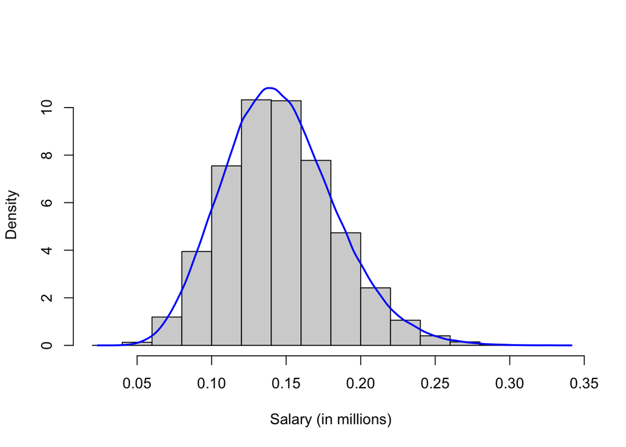

Salary distribution.

Since the median is lower than the mean, the data is slightly right-skewed.

Table 1) Salary descriptive statistics

| statistic | value |
| --- | --- |
| Min | 31867 |
| Mean | 145718.08 |
| Median | 143453 |
| Max | 333046 |
| StdDev | 37407.95 |

#Modeling

##Model 1

We fitted a linear regression model using all the predictors, with salary as the predicted variable.The estimates for the coefficients, standard errors and significance results are displayed below:

Summary of coefficients for model 1.

|  | Estimate | Std. Error | t value | Pr(>\|t\|) |
| --- | --- | --- | --- | --- |
| (Intercept) | 146739.297218 | 99.261495 | 1478.3103655 | 0.0000000 |
| job_titleBackend Developer | -34409.353302 | 69.809940 | -492.9004816 | 0.0000000 |
| job_titleBusiness Analyst | -51570.078694 | 70.209192 | -734.5203325 | 0.0000000 |
| job_titleCloud Engineer | -21525.446790 | 70.176614 | -306.7324782 | 0.0000000 |
| job_titleCybersecurity Analyst | -24705.556779 | 69.945898 | -353.2095184 | 0.0000000 |
| job_titleData Analyst | -53786.744693 | 70.146657 | -766.7755932 | 0.0000000 |
| job_titleData Scientist | -26927.693748 | 70.004984 | -384.6539518 | 0.0000000 |
| job_titleDevOps Engineer | -23770.396116 | 70.005476 | -339.5505254 | 0.0000000 |
| job_titleFrontend Developer | -40914.297607 | 70.222215 | -582.6403764 | 0.0000000 |
| job_titleMachine Learning Engineer | -10727.889704 | 70.185487 | -152.8505408 | 0.0000000 |
| job_titleProduct Manager | -16166.146186 | 69.954565 | -231.0949440 | 0.0000000 |
| job_titleSoftware Engineer | -32293.147714 | 70.015833 | -461.2263584 | 0.0000000 |
| experience_years | 2697.076675 | 2.362575 | 1141.5836076 | 0.0000000 |
| education_levelDiploma | -5330.889845 | 45.340910 | -117.5735079 | 0.0000000 |
| education_levelHigh School | -10712.143786 | 45.275905 | -236.5970096 | 0.0000000 |
| education_levelMaster | 10808.343877 | 45.213557 | 239.0509510 | 0.0000000 |
| education_levelPhD | 21556.889935 | 45.323515 | 475.6226392 | 0.0000000 |
| skills_count | 857.951518 | 2.613253 | 328.3079160 | 0.0000000 |
| industryEducation | 75.798816 | 63.941847 | 1.1854336 | 0.2358472 |
| industryFinance | 55.119220 | 63.621947 | 0.8663554 | 0.3862961 |
| industryGovernment | 106.216410 | 63.934336 | 1.6613359 | 0.0966473 |
| industryHealthcare | 75.443079 | 63.936437 | 1.1799700 | 0.2380133 |
| industryManufacturing | 13.060797 | 63.857433 | 0.2045306 | 0.8379391 |
| industryMedia | 94.894863 | 63.848459 | 1.4862514 | 0.1372139 |
| industryRetail | 86.236130 | 63.973656 | 1.3479944 | 0.1776614 |
| industryTechnology | 60.042396 | 63.932378 | 0.9391547 | 0.3476522 |
| industryTelecom | 45.173266 | 63.961443 | 0.7062578 | 0.4800285 |
| company_sizeLarge | -14095.834397 | 45.250956 | -311.5035748 | 0.0000000 |
| company_sizeMedium | -28270.787663 | 45.302021 | -624.0513567 | 0.0000000 |
| company_sizeSmall | -35381.225244 | 45.254660 | -781.8250184 | 0.0000000 |
| company_sizeStartup | -42367.764939 | 45.396113 | -933.2905755 | 0.0000000 |
| locationCanada | 27947.671390 | 63.765383 | 438.2890872 | 0.0000000 |
| locationGermany | 14030.206276 | 64.022948 | 219.1433958 | 0.0000000 |
| locationIndia | -41833.750183 | 63.938330 | -654.2828068 | 0.0000000 |
| locationNetherlands | -30.207911 | 63.960393 | -0.4722909 | 0.6367196 |
| locationRemote | -2.970812 | 63.829163 | -0.0465432 | 0.9628774 |
| locationSingapore | 20.505700 | 63.847925 | 0.3211647 | 0.7480858 |
| locationSweden | -26.311298 | 63.806197 | -0.4123627 | 0.6800739 |
| locationUK | 20979.820861 | 63.917378 | 328.2334383 | 0.0000000 |
| locationUSA | 41940.355686 | 63.915126 | 656.1882669 | 0.0000000 |
| remote_workNo | 36.225400 | 35.029161 | 1.0341498 | 0.3010671 |
| remote_workYes | 5354.281032 | 35.103207 | 152.5296811 | 0.0000000 |
| certifications | 1615.901263 | 8.391013 | 192.5752188 | 0.0000000 |

#model 2 planning on using random forest, but not done

#References [1] https://www.kaggle.com/datasets/nalisha/job-salary-prediction-dataset